# Faculdade Senac DF - Laboratório de Inovação II

Avaliação 2º bimestre de 2025.1

Author

Affiliation

Victória Ferreira Santos, Kauâ Oliveira Gonçalves

Faculdade SENAC DF

Published

25/06/2025

# 🧪 Avaliação Prática – 2º bimestre de 2025.1

# 🧪 Instruções gerais

> Você deve trabalhar com o dataset fornecido chamado milsa.csv.

O dataset fornecido contém informações de 36 funcionários da empresa Milsa, com variáveis que descrevem características demográficas, profissionais e salariais. As variáveis presentes são: identificação do funcionário, estado civil (solteiro ou casado), nível de escolaridade (1º Grau, 2º Grau ou Superior), número de filhos (com alguns valores faltando – NA), salário mensal em mil reais, idade em anos, tempo na empresa em meses e região de trabalho (capital, interior ou outro). Este conjunto de dados permite análises descritivas básicas, como distribuição salarial, composição familiar e grau de instrução dos colaboradores, além da criação de tabelas e gráficos para melhor visualização das informações.

> Ao final da avaliação, você deverá renderizar seu documento para HTML e enviar o arquivo resultante no Moodle. A avaliação tem como foco práticas de importação de dados, limpeza, formatação de tabelas e visualização gráfica.

## Instalação e carregamento de bibliotecas necessárias à realização das tarefas

**Ocultar/mostrar**

```r
#| echo: false
#| eval: true
#| message: false
#| warning: false


# devtools::install_github("yutannihilation/ggsflabel")

   # Testa se o pacote "pacman" está instalado. Se necessário, faz a instalação
if (!require(pacman)) install.packages("pacman")

pacman::p_load(tidyverse,   # Família de pacotes para manipulação de dados
               kableExtra,
               rmarkdown,
               ggplot2,
               ggthemes,
               skimr,
               corrplot,
               DataExplorer,
               httr,
               jsonlite,
               lubridate,
               xlsx,
               readr,
               dplyr)


options(scipen = 999)
```

## 📌 Questão 1 – Importação do Dataset (1 ponto)

- Carregue o dataset milsa.csv para o RStudio.
- Exiba as primeiras 6 linhas do dataset usando a função head().
- Verifique a estrutura das variáveis com a função str().

**Ocultar/mostrar**

```r
## Carregar o dataset

dataset <- read_csv("milsa.csv")


# Exibir primeiras linhas

head(dataset)
```

```
# A tibble: 6 × 9
   ...1 Funcionario Est.civil Inst    Filhos Salario  Anos Meses Regiao
  <dbl>       <dbl> <chr>     <chr>    <dbl>   <dbl> <dbl> <dbl> <chr>
1     1           1 solteiro  1o Grau     NA    4       26     3 interior
2     2           2 casado    1o Grau      1    4.56    32    10 capital
3     3           3 casado    1o Grau      2    5.25    36     5 capital
4     4           4 solteiro  2o Grau     NA    5.73    20    10 outro
5     5           5 solteiro  1o Grau     NA    6.26    40     7 outro
6     6           6 casado    1o Grau      0    6.66    28     0 interior
```

**Ocultar/mostrar**

```r
# Estrutura das variáveis

str(dataset)
```

```
spc_tbl_ [36 × 9] (S3: spec_tbl_df/tbl_df/tbl/data.frame)
 $ ...1       : num [1:36] 1 2 3 4 5 6 7 8 9 10 ...
 $ Funcionario: num [1:36] 1 2 3 4 5 6 7 8 9 10 ...
 $ Est.civil  : chr [1:36] "solteiro" "casado" "casado" "solteiro" ...
 $ Inst       : chr [1:36] "1o Grau" "1o Grau" "1o Grau" "2o Grau" ...
 $ Filhos     : num [1:36] NA 1 2 NA NA 0 NA NA 1 NA ...
 $ Salario    : num [1:36] 4 4.56 5.25 5.73 6.26 6.66 6.86 7.39 7.59 7.44 ...
 $ Anos       : num [1:36] 26 32 36 20 40 28 41 43 34 23 ...
 $ Meses      : num [1:36] 3 10 5 10 7 0 0 4 10 6 ...
 $ Regiao     : chr [1:36] "interior" "capital" "capital" "outro" ...
 - attr(*, "spec")=
  .. cols(
  ..   ...1 = col_double(),
  ..   Funcionario = col_double(),
  ..   Est.civil = col_character(),
  ..   Inst = col_character(),
  ..   Filhos = col_double(),
  ..   Salario = col_double(),
  ..   Anos = col_double(),
  ..   Meses = col_double(),
  ..   Regiao = col_character()
  .. )
 - attr(*, "problems")=<externalptr>
```

## 📌 Questão 2 – Limpeza e Organização do Dataset (2,0 pontos)

> Renomeie as colunas do dataset para nomes mais descritivos:
- Funcionario → ID
- Est.civil → EstadoCivil
- Inst → Escolaridade
- Filhos → NumFilhos
- Salario → SalarioMilReais
- Anos → Idade
- Meses → TempoEmpresaMeses
- Regiao → RegiaoTrabalho

> Converta a variável NumFilhos para tipo numérico, caso não esteja.

> Crie uma nova variável chamada SalarioAnualMilReais, que seja igual ao salário mensal multiplicado por 12.

**Ocultar/mostrar**

```r
# Renomear colunas
dataset <- dataset %>%
  rename(
    ID = Funcionario,
    EstadoCivil = Est.civil,
    Escolaridade = Inst,
    NumFilhos = Filhos,
    SalarioMilReais = Salario,
    Idade = Anos,
    TempoEmpresaMeses = Meses,
    RegiaoTrabalho = Regiao
  )

# Converter NumFilhos para numérico (NA permanece como NA)
dataset$NumFilhos <- as.numeric(dataset$NumFilhos)

# Criar nova variável: salário anual
dataset$SalarioAnualMilReais <- dataset$SalarioMilReais * 12

# Exibir primeiras linhas após limpeza
head(dataset)
```

```
# A tibble: 6 × 10
   ...1    ID EstadoCivil Escolaridade NumFilhos SalarioMilReais Idade
  <dbl> <dbl> <chr>       <chr>            <dbl>           <dbl> <dbl>
1     1     1 solteiro    1o Grau             NA            4       26
2     2     2 casado      1o Grau              1            4.56    32
3     3     3 casado      1o Grau              2            5.25    36
4     4     4 solteiro    2o Grau             NA            5.73    20
5     5     5 solteiro    1o Grau             NA            6.26    40
6     6     6 casado      1o Grau              0            6.66    28
# ℹ 3 more variables: TempoEmpresaMeses <dbl>, RegiaoTrabalho <chr>,
#   SalarioAnualMilReais <dbl>
```

## 📌 Questão 3 – Tabela Formatada com KableExtra (2 pontos)

> Selecione as seguintes variáveis para compor uma tabela:
- ID
- EstadoCivil
- Escolaridade
- NumFilhos
- SalarioMilReais
- RegiaoTrabalho

> Use o pacote kableExtra para formatar essa tabela com título, alinhamento adequado e cores suaves.

**Ocultar/mostrar**

```r
# Selecionar variáveis de interesse

tabela_interesse <- dataset %>%
  select(ID, EstadoCivil, Escolaridade, NumFilhos, SalarioMilReais, RegiaoTrabalho)



# Formatar tabela

tabela_interesse %>%
  kbl(
    caption = "Tabela 1 – Perfil dos Funcionários Milsa",
    align = "c",
    format = "html"
  ) %>%
  kable_styling(
    bootstrap_options = c("striped", "hover", "condensed", "responsive"),
    full_width = FALSE,
    position = "center"
  ) %>%
  row_spec(0, bold = TRUE, background = "#3FB839")
```

Tabela 1 – Perfil dos Funcionários Milsa

| ID | EstadoCivil | Escolaridade | NumFilhos | SalarioMilReais | RegiaoTrabalho |
| --- | --- | --- | --- | --- | --- |
| 1 | solteiro | 1o Grau | NA | 4.00 | interior |
| 2 | casado | 1o Grau | 1 | 4.56 | capital |
| 3 | casado | 1o Grau | 2 | 5.25 | capital |
| 4 | solteiro | 2o Grau | NA | 5.73 | outro |
| 5 | solteiro | 1o Grau | NA | 6.26 | outro |
| 6 | casado | 1o Grau | 0 | 6.66 | interior |
| 7 | solteiro | 1o Grau | NA | 6.86 | interior |
| 8 | solteiro | 1o Grau | NA | 7.39 | capital |
| 9 | casado | 2o Grau | 1 | 7.59 | capital |
| 10 | solteiro | 2o Grau | NA | 7.44 | outro |
| 11 | casado | 2o Grau | 2 | 45999.00 | interior |
| 12 | solteiro | 1o Grau | NA | 8.46 | capital |
| 13 | solteiro | 2o Grau | NA | 8.74 | outro |
| 14 | casado | 1o Grau | 3 | 8.95 | outro |
| 15 | casado | 2o Grau | 0 | 9.13 | interior |
| 16 | solteiro | 2o Grau | NA | 9.35 | outro |
| 17 | casado | 2o Grau | 1 | 9.77 | capital |
| 18 | casado | 1o Grau | 2 | 45878.00 | outro |
| 19 | solteiro | Superior | NA | 10.53 | interior |
| 20 | solteiro | 2o Grau | NA | 10.76 | interior |
| 21 | casado | 2o Grau | 1 | 45819.00 | outro |
| 22 | solteiro | 2o Grau | NA | 11.59 | capital |
| 23 | solteiro | 1o Grau | NA | 12.00 | outro |
| 24 | casado | Superior | 0 | 12.79 | outro |
| 25 | casado | 2o Grau | 2 | 13.23 | interior |
| 26 | casado | 2o Grau | 2 | 45821.00 | outro |
| 27 | solteiro | 1o Grau | NA | 13.85 | outro |
| 28 | casado | 2o Grau | 0 | 14.69 | interior |
| 29 | casado | 2o Grau | 5 | 14.71 | interior |
| 30 | casado | 2o Grau | 2 | 15.99 | capital |
| 31 | solteiro | Superior | NA | 16.22 | outro |
| 32 | casado | 2o Grau | 1 | 16.61 | interior |
| 33 | casado | Superior | 3 | 17.26 | capital |
| 34 | solteiro | Superior | NA | 18.75 | capital |
| 35 | casado | 2o Grau | 2 | 45766.00 | capital |
| 36 | casado | Superior | 3 | 45739.00 | interior |

## 📌 Questão 4 – Gráfico de Barras (2.5 pontos)

> Construa um gráfico de barras mostrando a média salarial por região de trabalho (RegiaoTrabalho).

> Ordene as regiões pela média salarial (do menor para o maior).

> Adicione título ao gráfico, rótulos aos eixos e cores diferenciadas por barra.

**Ocultar/mostrar**

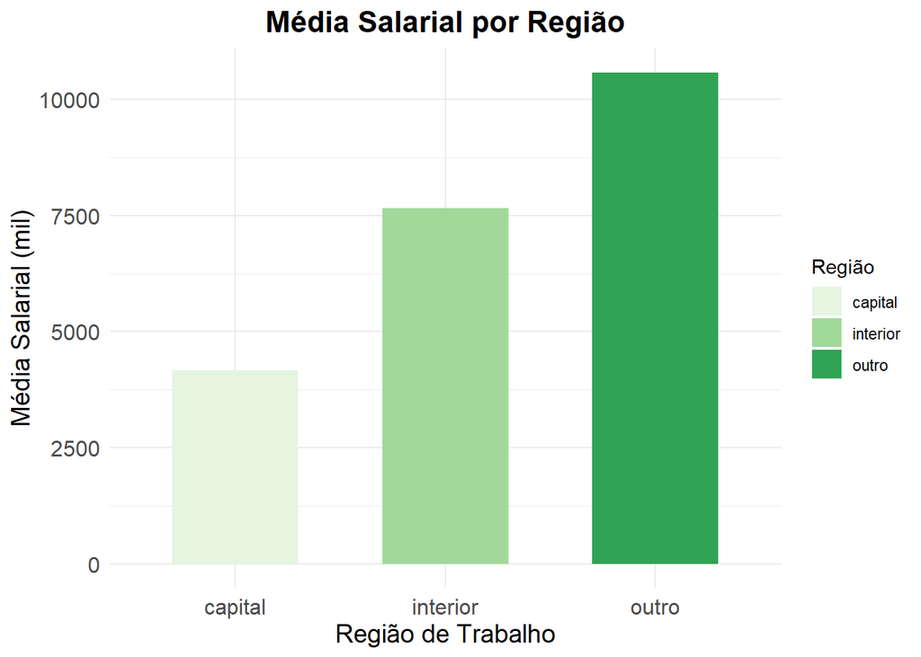

```r
# Calcular média salarial por região

media_salario_regiao <- dataset %>%
  group_by(RegiaoTrabalho) %>%
  summarise(MediaSalario = mean(SalarioMilReais, na.rm = TRUE)) %>%
  arrange(MediaSalario)




# Plotar gráfico de barras

ggplot(media_salario_regiao, aes(x = reorder(RegiaoTrabalho, MediaSalario), y = MediaSalario, fill = RegiaoTrabalho)) +
  geom_bar(stat = "identity", width = 0.6) +
  scale_fill_brewer(palette = "Pastel") +
  labs(
    title = "Média Salarial por Região",
    x = "Região de Trabalho",
    y = "Média Salarial (mil)",
    fill = "Região"
  ) +
  theme_minimal() +
  theme(
    plot.title = element_text(hjust = 0.5, size = 16, face = "bold"),
    axis.title = element_text(size = 14),
    axis.text = element_text(size = 12)
  )
```